# 1.A. Refer above table and find the joint probability of the people who planned to purchase and actually placed an order

# 4. Accuracy in understanding orders for a speech based bot at a restaurant is important for the Company X which has designed,marketed and launched the product for a contactless delivery due to the COVID-19 pandemic. Recognition accuracy that measures the percentage of orders that are taken correctly is 86.8%. Suppose that you place an order with the bot and two friends of yours independently place orders with the same bot. Answer the following questions.

```python
sample_size = 3
Percentage_of_orders = 0.868

K = np.arange(0,5)
K
```

```
array([0, 1, 2, 3, 4])
```

```python
#4.A.What is the probability that all three orders will be recognised correctly?

binomial1 = stats.binom.pmf(1,3,0.868) + stats.binom.pmf(2,3,0.868) + stats.binom.pmf(3,3,0.868)

print('The probability that all three orders will be recognised correctly is',binomial1*100,'%')
```

[output not shown]

```python
#4.B.What is the probability that none of the three orders will be recognised correctly?

binomial2 = stats.binom.pmf(0,3,0.868)

print('The probability that none of the three orders will be recognised correctly is',binomial2*100,"%")
```

```
The probability that none of the three orders will be recognised correctly is 0.22999680000000003 %
```

```python
#4.C.What is the probability that at least two of the three orders will be recognised correctly?

binomial3 = stats.binom.pmf(1,3,0.868) + stats.binom.pmf(2,3,0.868)

rint('The probability that at least two of the three orders will be recognised correctly is',binomial3*100,'%')
```

[output not shown]

# 5. Real life industry scenario - Online travel company Goibibo has a chatbot to handle customer queries. As per past records, the chatbot provides accurate resolutions to customer queries in 78.5% of cases.Based on a sample of 10 random chats.

```python
sample_chats = 10
Success_rate = 0.785

number_of_chats = np.arange(0,11)
number_of_chats
```

```
array([ 0,  1,  2,  3,  4,  5,  6,  7,  8,  9, 10])
```

```python
#1.accurate resolutions to customer queries not provided in any of the chats
binomial4=stats.binom.pmf(0,10,0.780)*100
print('accurate resolutions to customer queries not provided in any of the chats',binomial4,'%')
```

```
accurate resolutions to customer queries not provided in any of the chats 2.6559922791423967e-05 %
```

```python
#2.accurate resolutions to customer queries are provided in all 10 chats

binomial6=(stats.binom.pmf(1,10,0.78)+stats.binom.pmf(2,10,0.78)+stats.binom.pmf(3,10,0.78)+stats.binom.pmf(4,10,0.78)+stats.binom.pmf(5,10,0.78)+stats.binom.pmf(6,10,0.78)+stats.binom.pmf(7,10,0.78)+stats.binom.pmf(8,10,0.78)+stats.binom.pmf(9,10,0.78)+stats.binom.pmf(10,10,0.78))*100
print('accurate resolutions to customer queries are provided in all 10 chats is',binomial6,'%')
```

[output not shown]

```python
#3.accurate resolutions to customer queries is provided for at least 5 chats

binomial6= stats.binom.pmf(1,10,0.78) + stats.binom.pmf(2,10,0.78) + stats.binom.pmf(3,10,0.78)+ stats.binom.pmf(4,10,0.78)+ stats.binom.pmf(5,5,0.80)
print('accurate resolutions to customer queries is provided for at least 3 chats is',binomial6*100,'%')
```

```
accurate resolutions to customer queries is provided for at least 3 chats is 33.80733022370778 %
```

# Company X manages the men's top professional basketball division of the American league system. The dataset contains informationon all the teams that have participated in all the past tournaments. It has data about how many baskets each team scored, conceded, how many times they came within the first 2 positions, how many tournaments they have qualified, their best position in the past, etc

```python
#Read the dataset
data= pd.read_csv("C:\\Users\\DELL\\Downloads\\Basketball.csv")
```

```python
data.head()
```

|  | Team | Tournament | Score | PlayedGames | WonGames | DrawnGames | LostGames | BasketScored | BasketGiven | TournamentChampion | Runner-up | TeamLaunch | HighestPositionHeld |
| --- | --- | --- | --- | --- | --- | --- | --- | --- | --- | --- | --- | --- | --- |
| 0 | Team 1 | 86 | 4385 | 2762 | 1647 | 552 | 563 | 5947 | 3140 | 33 | 23 | 1929 | 1 |
| 1 | Team 2 | 86 | 4262 | 2762 | 1581 | 573 | 608 | 5900 | 3114 | 25 | 25 | 1929 | 1 |
| 2 | Team 3 | 80 | 3442 | 2614 | 1241 | 598 | 775 | 4534 | 3309 | 10 | 8 | 1929 | 1 |
| 3 | Team 4 | 82 | 3386 | 2664 | 1187 | 616 | 861 | 4398 | 3469 | 6 | 6 | 1931to32 | 1 |
| 4 | Team 5 | 86 | 3368 | 2762 | 1209 | 633 | 920 | 4631 | 3700 | 8 | 7 | 1929 | 1 |

```python
#1.Check for null values
data.isna().sum()
```

```
Team                   0
Tournament             0
Score                  0
PlayedGames            0
WonGames               0
DrawnGames             0
LostGames              0
BasketScored           0
BasketGiven            0
TournamentChampion     0
Runner-up              0
TeamLaunch             0
HighestPositionHeld    0
dtype: int64
```

```python
#2. check data information,count and data type etc
data.info()
```

```
<class 'pandas.core.frame.DataFrame'>
RangeIndex: 61 entries, 0 to 60
Data columns (total 13 columns):
 #   Column               Non-Null Count  Dtype
---  ------               --------------  -----
 0   Team                 61 non-null     object
 1   Tournament           61 non-null     int64
 2   Score                61 non-null     object
 3   PlayedGames          61 non-null     object
 4   WonGames             61 non-null     object
 5   DrawnGames           61 non-null     object
 6   LostGames            61 non-null     object
 7   BasketScored         61 non-null     object
 8   BasketGiven          61 non-null     object
 9   TournamentChampion   61 non-null     object
 10  Runner-up            61 non-null     object
 11  TeamLaunch           61 non-null     object
 12  HighestPositionHeld  61 non-null     int64
dtypes: int64(2), object(11)
memory usage: 6.3+ KB
```

```python
#3.Check for duplicates
duplicates = data.duplicated()
sum(duplicates)
```

```
0
```

```python
data.tail()
```

|  | Team | Tournament | Score | PlayedGames | WonGames | DrawnGames | LostGames | BasketScored | BasketGiven | TournamentChampion | Runner-up | TeamLaunch | HighestPositionHeld |
| --- | --- | --- | --- | --- | --- | --- | --- | --- | --- | --- | --- | --- | --- |
| 56 | Team 57 | 1 | 34 | 38 | 8 | 10 | 20 | 38 | 66 | - | - | 2009-10 | 20 |
| 57 | Team 58 | 1 | 22 | 30 | 7 | 8 | 15 | 37 | 57 | - | - | 1956-57 | 16 |
| 58 | Team 59 | 1 | 19 | 30 | 7 | 5 | 18 | 51 | 85 | - | - | 1951~52 | 16 |
| 59 | Team 60 | 1 | 14 | 30 | 5 | 4 | 21 | 34 | 65 | - | - | 1955-56 | 15 |
| 60 | Team 61 | 1 | - | - | - | - | - | - | - | - | - | 2017~18 | 9 |

```python
#CHeck unique values count
print("TournamentChampion",data['TournamentChampion'].unique())
```

```
TournamentChampion ['33' '25' '10' '6' '8' '1' '-' '2']
```

```python
print("Runner-up",data['Runner-up'].unique())
```

```
Runner-up ['23' '25' '8' '6' '7' '4' '-' '3' '1' '5']
```

```python
print("Score",data['Score'].unique())
```

```
Score ['4385' '4262' '3442' '3386' '3368' '2819' '2792' '2573' '2109' '1884'
 '1814' '1789' '1471' '1416' '1389' '1351' '1314' '1174' '1148' '1020'
 '970' '667' '662' '606' '553' '538' '510' '445' '421' '416' '375' '353'
 '343' '293' '285' '277' '242' '230' '190' '188' '168' '150' '148' '132'
 '107' '96' '91' '83' '81' '76' '71' '56' '52' '42' '40' '35' '34' '22'
 '19' '14' '-']
```

```python
#Renames team column by reaplcing team with T to avoid null values in the further methods/visualization
data['Team']=data['Team'].str.replace('Team ','T');
columns = data.columns.drop('Team');

#Datatypes are object hence change them to integers to get further insights around the data
data[columns] = data[columns].apply(pd.to_numeric, errors='coerce')
```

```python
data=data.replace('-',0); #Replacing - with 0 to have similar values in dataset.
```

```python
data.tail()
```

|  | Team | Tournament | Score | PlayedGames | WonGames | DrawnGames | LostGames | BasketScored | BasketGiven | TournamentChampion | Runner-up | TeamLaunch | HighestPositionHeld |
| --- | --- | --- | --- | --- | --- | --- | --- | --- | --- | --- | --- | --- | --- |
| 56 | T57 | 1 | 34.0 | 38.0 | 8.0 | 10.0 | 20.0 | 38.0 | 66.0 | NaN | NaN | NaN | 20 |
| 57 | T58 | 1 | 22.0 | 30.0 | 7.0 | 8.0 | 15.0 | 37.0 | 57.0 | NaN | NaN | NaN | 16 |
| 58 | T59 | 1 | 19.0 | 30.0 | 7.0 | 5.0 | 18.0 | 51.0 | 85.0 | NaN | NaN | NaN | 16 |
| 59 | T60 | 1 | 14.0 | 30.0 | 5.0 | 4.0 | 21.0 | 34.0 | 65.0 | NaN | NaN | NaN | 15 |
| 60 | T61 | 1 | NaN | NaN | NaN | NaN | NaN | NaN | NaN | NaN | NaN | NaN | 9 |

```python
data.info()
```

```
<class 'pandas.core.frame.DataFrame'>
RangeIndex: 61 entries, 0 to 60
Data columns (total 13 columns):
 #   Column               Non-Null Count  Dtype
---  ------               --------------  -----
 0   Team                 61 non-null     object
 1   Tournament           61 non-null     int64
 2   Score                60 non-null     float64
 3   PlayedGames          60 non-null     float64
 4   WonGames             60 non-null     float64
 5   DrawnGames           60 non-null     float64
 6   LostGames            60 non-null     float64
 7   BasketScored         60 non-null     float64
 8   BasketGiven          60 non-null     float64
 9   TournamentChampion   9 non-null      float64
 10  Runner-up            13 non-null     float64
 11  TeamLaunch           10 non-null     float64
 12  HighestPositionHeld  61 non-null     int64
dtypes: float64(10), int64(2), object(1)
memory usage: 6.3+ KB
```

```python
#Removed team 61 since it had 0 values in most fields
data.drop(60,inplace=True)
```

```python
#EDA and statistical analysis
data.describe(include="all")
```

|  | Team | Tournament | Score | PlayedGames | WonGames | DrawnGames | LostGames | BasketScored | BasketGiven | TournamentChampion | Runner-up | TeamLaunch | HighestPositionHeld |
| --- | --- | --- | --- | --- | --- | --- | --- | --- | --- | --- | --- | --- | --- |
| count | 60 | 60.000000 | 60.000000 | 60.000000 | 60.000000 | 60.000000 | 60.000000 | 60.000000 | 60.000000 | 9.000000 | 13.000000 | 10.0 | 60.000000 |
| unique | 60 | NaN | NaN | NaN | NaN | NaN | NaN | NaN | NaN | NaN | NaN | NaN | NaN |
| top | T1 | NaN | NaN | NaN | NaN | NaN | NaN | NaN | NaN | NaN | NaN | NaN | NaN |
| freq | 1 | NaN | NaN | NaN | NaN | NaN | NaN | NaN | NaN | NaN | NaN | NaN | NaN |
| mean | NaN | 24.383333 | 916.450000 | 810.100000 | 309.033333 | 192.083333 | 308.816667 | 1159.350000 | 1159.233333 | 9.666667 | 6.615385 | 1929.0 | 7.050000 |
| std | NaN | 26.884620 | 1138.342899 | 877.465393 | 408.481395 | 201.985508 | 294.508639 | 1512.063948 | 1163.946914 | 11.618950 | 8.109033 | 0.0 | 5.315232 |
| min | NaN | 1.000000 | 14.000000 | 30.000000 | 5.000000 | 4.000000 | 15.000000 | 34.000000 | 55.000000 | 1.000000 | 1.000000 | 1929.0 | 1.000000 |
| 25% | NaN | 4.000000 | 104.250000 | 115.500000 | 34.750000 | 26.250000 | 62.750000 | 154.500000 | 236.000000 | 1.000000 | 1.000000 | 1929.0 | 3.000000 |
| 50% | NaN | 12.000000 | 395.500000 | 424.500000 | 124.000000 | 98.500000 | 197.500000 | 444.000000 | 632.500000 | 6.000000 | 4.000000 | 1929.0 | 6.000000 |
| 75% | NaN | 39.000000 | 1360.500000 | 1345.500000 | 432.750000 | 331.500000 | 563.500000 | 1669.750000 | 2001.250000 | 10.000000 | 7.000000 | 1929.0 | 10.000000 |
| max | NaN | 86.000000 | 4385.000000 | 2762.000000 | 1647.000000 | 633.000000 | 1070.000000 | 5947.000000 | 3889.000000 | 33.000000 | 25.000000 | 1929.0 | 20.000000 |

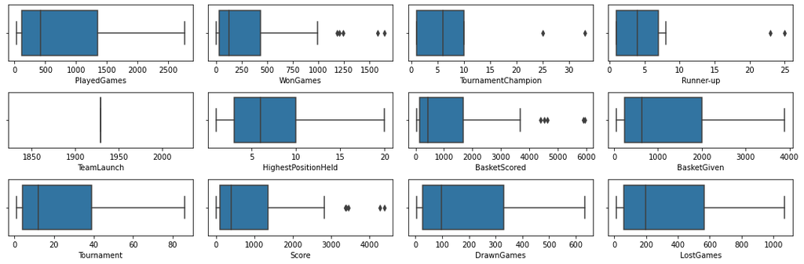

```python
#box plots to understand that each column, check skewness and outliers
box_plot, ax = plt.subplots(3,4)

box_plot.set_figheight(5)
box_plot.set_figwidth(15)

sns.boxplot(x=data['PlayedGames'],ax=ax[0][0])
sns.boxplot(x=data['WonGames'],ax=ax[0][1])
sns.boxplot(x=data['TournamentChampion'],ax=ax[0][2])
sns.boxplot(x=data['Runner-up'],ax=ax[0][3])
sns.boxplot(x=data['TeamLaunch'],ax=ax[1][0])
sns.boxplot(x=data['HighestPositionHeld'],ax=ax[1][1])
sns.boxplot(x=data['BasketScored'],ax=ax[1][2])
sns.boxplot(x=data['BasketGiven'],ax=ax[1][3])
sns.boxplot(x=data['Tournament'],ax=ax[2][0])
sns.boxplot(x=data['Score'],ax=ax[2][1])
sns.boxplot(x=data['DrawnGames'],ax=ax[2][2])
sns.boxplot(x=data['LostGames'],ax=ax[2][3])

box_plot.tight_layout()
```